# MATH9102-Phase2-Task4

# Introduction

Complete the PCA making relevant decisions and report your findings. https://www.kaggle.com/datasets/hayriyigit/website-satisfaction-survey

These are the variables of interest to this task:

*Navigation:*

| **Variable** | **Meaning** |
| --- | --- |
| **q1** | Ease of navigating the website |
| **q2** | Clarity of the menu/structure |
| **q3** | Ease of finding information |
| **q4** | Website is intuitive to use |
| **q5** | Layout helps navigation |

*Typography:*

| **Variable** | **Meaning** |
| --- | --- |
| **q9** | Text readability and formatting |

*Colour:*

| **Variable** | **Meaning** |
| --- | --- |
| **q7** | Colour scheme suitability |
| **q8** | Layout attractiveness (partly colour-related) |

*Interactivity:*

| **Variable** | **Meaning** |
| --- | --- |
| **q15** | Website loading speed (affects perceived interactivity) |
| **q16** | Reliability / absence of errors (supports smooth interaction) |
| **q17** | Responsiveness on device (directly interactive behaviour) |

**Note:** Throughout the code, placeholders have been included for some steps e.g. step 5 retains 8 components, step 6 uses all the data. However, you need to make decisions based on your interpretation of the outcomes of the relevant steps.

**WHAT YOU NEED TO DO:**

- **Step 2:** Review the outcomes and write a report on the suitability of the dataset for dimension reduction.
- **Step 3 and Step 4:** Review the outcomes and decide how many components you wish to retain. Adjust any visualizations you need to.
- **Step 5:** Adjust the code to retain the required number of components and apply rotation. Write a report on the outcome of the PCA.
- **Step 6:** Complete the code to conduct the reliability analysis. Write the report on the reliability of the data.
- **Conclusion:** Write a conclusion on the success and usefulness (or otherwise) of the PCA.

# STEP 1: Create and screen the correlation matrix for the uxData dataset

## Step 1a: Create the matrix

You can change this to use another approach if you wish.

```r
#create a correlation matrix
uxMatrix<-cor(uxData)
round(uxMatrix, 2)
```

```
      q1   q2   q3   q4   q5   q9   q7   q8  q15  q16  q17
q1  1.00 0.73 0.60 0.57 0.61 0.03 0.46 0.33 0.41 0.10 0.32
q2  0.73 1.00 0.59 0.74 0.63 0.19 0.35 0.38 0.39 0.22 0.38
q3  0.60 0.59 1.00 0.65 0.55 0.19 0.31 0.42 0.31 0.19 0.39
q4  0.57 0.74 0.65 1.00 0.59 0.07 0.22 0.38 0.30 0.23 0.30
q5  0.61 0.63 0.55 0.59 1.00 0.33 0.50 0.48 0.56 0.31 0.51
q9  0.03 0.19 0.19 0.07 0.33 1.00 0.35 0.48 0.50 0.58 0.41
q7  0.46 0.35 0.31 0.22 0.50 0.35 1.00 0.51 0.61 0.40 0.67
q8  0.33 0.38 0.42 0.38 0.48 0.48 0.51 1.00 0.59 0.42 0.64
q15 0.41 0.39 0.31 0.30 0.56 0.50 0.61 0.59 1.00 0.45 0.66
q16 0.10 0.22 0.19 0.23 0.31 0.58 0.40 0.42 0.45 1.00 0.54
q17 0.32 0.38 0.39 0.30 0.51 0.41 0.67 0.64 0.66 0.54 1.00
```

All the variables correlate with at least one other at .3 or above (absolute values) and nothing above .8:

[output not shown]

## Step 1b: Visualize the correlation matrix

You can change this to use another visualizatin if you wish.

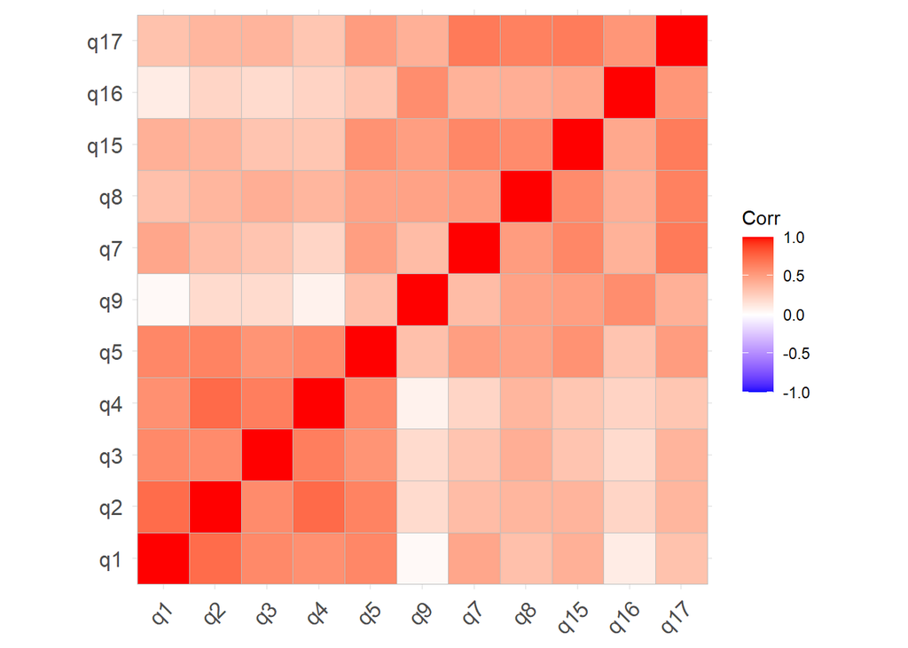

Figure 1: Basic Correlation Matrix

```r
# 1. Basic correlation matrix plot
ggcorrplot::ggcorrplot(uxMatrix)
```

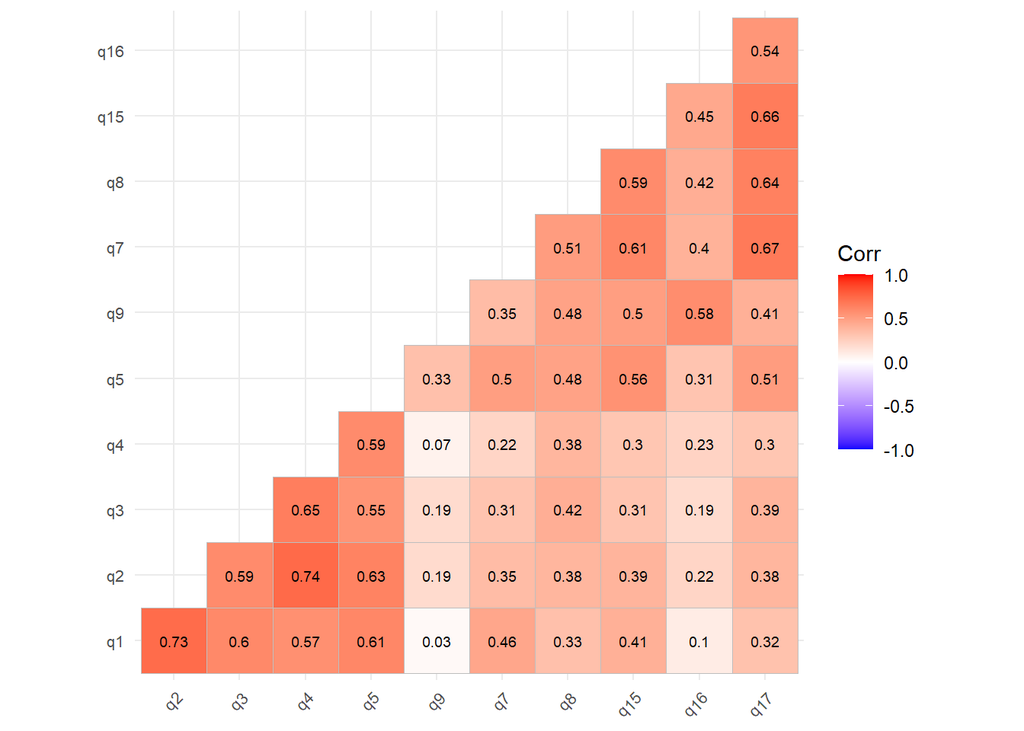

Figure 1: Correlation Matrix - uxData Dataset

```r
# 5. Correlation matrix showing coefficients with labels
# Note: This can become cluttered with a high number of variables
#| fig-width: 16
#| fig-height: 16

ggcorrplot::ggcorrplot(
  uxMatrix,
  lab = TRUE,
  lab_size = 2.5,
  tl.cex = 8,
  tl.srt = 45,
  type = "lower"
)
```